# Chapter 8 — Independence, Proportions, and Relative Risk (R companion)

R/tidyverse translation of *Understanding Data by Alan Garfinkel and Yina Guo

Adrian Soto-Mota, MD, PhD, FACP.

2026-04-24

# Orientation

Chapter 8 (book pp. 366–447) works with count data: are two proportions the same, are observations independent of group membership, what’s the relative risk? The chapter’s approach is **simulation-based χ-square** — translated below from the book’s Python snippets at **p. 379**.

# §8.1 — Observed vs expected histograms *(book §8.1 “Comparing histograms of observations to expectations”, p. 367)*

Suppose we observe 12 balls drawn from an urn:

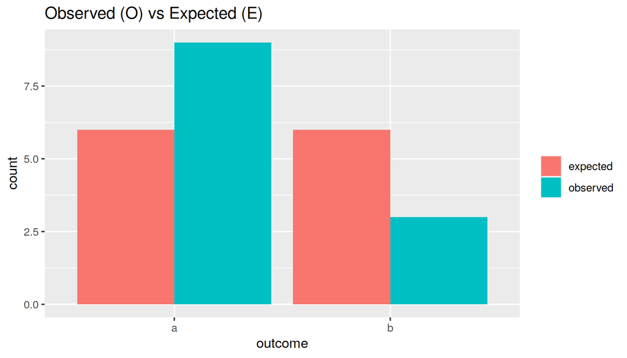

```r
observed <- c(a = 9, b = 3)       # observed frequencies
n        <- sum(observed)
outcomes <- names(observed)

# Under the null, balls are equally likely: E(a) = E(b) = 6
expected <- c(a = n/2, b = n/2)

tibble(outcome  = names(observed),
       observed = observed,
       expected = expected) |>
  pivot_longer(c(observed, expected)) |>
  ggplot(aes(outcome, value, fill = name)) +
  geom_col(position = "dodge") +
  labs(title = "Observed (O) vs Expected (E)", y = "count", fill = NULL)
```

# §8.2 — The distance χ between observation and expectation *(book p. 373)*

The chapter’s definition (simpler than the textbook χ²):

$$\chi = \sum_i \frac{|O_i -
E_i|}{\sqrt{E_i}}$$

```r
chi_distance <- function(O, E) sum(abs(O - E) / sqrt(E))
chi_obs <- chi_distance(observed, expected)
chi_obs
```

```
## [1] 2.44949
```

Compare to the classical χ² statistic:

```r
chi2_classical <- function(O, E) sum((O - E)^2 / E)
chi2_classical(observed, expected)
```

```
## [1] 3
```

# §8.3 — Is χ_obs “large”? NHST by sampling with replacement *(book p. 377)*

**Chapter’s Python (reproduced from book p. 379):**

```python
import numpy as np
outcomes = ['a', 'b']
n = 12
p_outcomes = [6/12, 6/12]
pseudo_observed = np.random.choice(
    outcomes, size=n, replace=True, p=p_outcomes)
```

**R translation:**

```r
n_sim <- 10000
null_chi <- numeric(n_sim)

for (i in seq_len(n_sim)) {
  # Draw n balls from the null distribution (equal proportions)
  pseudo_observed <- sample(outcomes, size = n, replace = TRUE,
                            prob = c(6/12, 6/12))
  # Count each outcome
  counts <- table(factor(pseudo_observed, levels = outcomes))
  # Distance from the expected
  null_chi[i] <- chi_distance(as.numeric(counts), expected)
}

p_value <- mean(null_chi >= chi_obs)
p_value
```

```
## [1] 0.1424
```

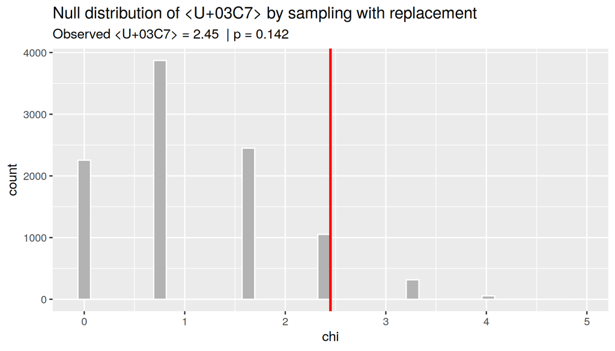

```r
tibble(chi = null_chi) |>
  ggplot(aes(chi)) +
  geom_histogram(bins = 40, fill = "grey70", color = "white") +
  geom_vline(xintercept = chi_obs, color = "red", linewidth = 1) +
  labs(title = "Null distribution of χ by sampling with replacement",
       subtitle = paste("Observed χ =", signif(chi_obs, 3),
                        " | p =", signif(p_value, 3)))
```

## Fractional expected counts *(book p. 379, second snippet)*

The chapter’s second Python snippet uses E(a) = 5.7, E(b) = 6.3:

```python
p_outcomes = [5.7/12, 6.3/12]
pseudo_observed = np.random.choice(
    outcomes, size=n, replace=True, p=p_outcomes)
```

R equivalent is just changing the `prob` argument:

```r
p_out <- c(a = 5.7/12, b = 6.3/12)
pseudo <- sample(outcomes, size = n, replace = TRUE, prob = p_out)
pseudo
```

```
##  [1] "a" "b" "a" "a" "b" "a" "b" "a" "b" "b" "b" "b"
```

# §8.4 — Post-hoc: the “Mt. Fuji plot” *(book p. 385)*

When there are many categories and the omnibus χ rejects the null, which categories are driving the signal? Compute a standardized residual per category and visualize.

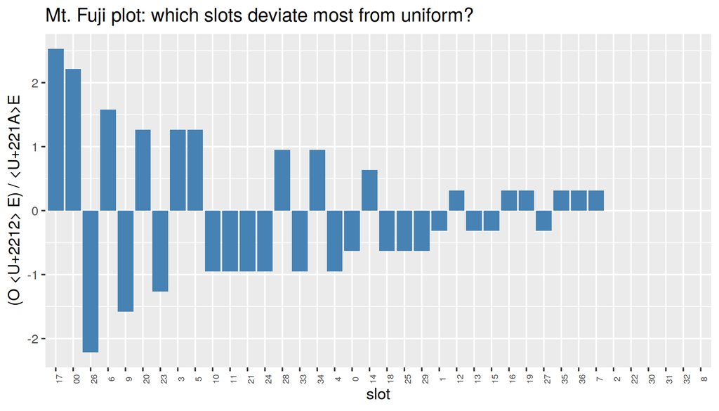

```r
# Roulette wheel example: 38 slots (0, 00, 1-36). Observed frequencies over 380 spins
set.seed(1)
obs_roulette <- rmultinom(1, size = 380,
                          prob = c(rep(1/38, 37), 2/38))[, 1]   # slot 38 biased
names(obs_roulette) <- c(as.character(0:36), "00")

exp_roulette <- rep(380 / 38, 38)
names(exp_roulette) <- names(obs_roulette)

# Signed standardized residual per slot: (O - E) / sqrt(E)
residuals_df <- tibble(
  slot       = names(obs_roulette),
  observed   = as.integer(obs_roulette),
  expected   = exp_roulette,
  residual   = (observed - expected) / sqrt(expected)
)

ggplot(residuals_df, aes(reorder(slot, -abs(residual)), residual)) +
  geom_col(fill = "steelblue") +
  labs(title = "Mt. Fuji plot: which slots deviate most from uniform?",
       x = "slot", y = "(O − E) / √E") +
  theme(axis.text.x = element_text(angle = 90, size = 6))
```

Slots with the tallest bars on either side are the biggest contributors.

# §8.5 — Comparing two observed histograms (2-D contingency) *(book p. 396)*

```r
# Clinical trial: treatment vs placebo, outcome = improved / not improved
trial <- matrix(c(40, 60,     # treatment:  40 improved, 60 not
                  20, 80),    # placebo:    20 improved, 80 not
                nrow = 2, byrow = TRUE,
                dimnames = list(arm = c("treatment", "placebo"),
                                outcome = c("improved", "not")))
trial
```

```
##            outcome
## arm         improved not
##   treatment       40  60
##   placebo         20  80
```

Build the expected table under independence (same improvement rate in both arms):

```r
row_totals <- rowSums(trial)
col_totals <- colSums(trial)
grand      <- sum(trial)

expected_trial <- outer(row_totals, col_totals) / grand
expected_trial
```

```
##           improved not
## treatment       30  70
## placebo         30  70
```

```r
chi_obs_trial <- sum(abs(trial - expected_trial) / sqrt(expected_trial))
chi_obs_trial
```

```
## [1] 6.041941
```

Permutation test: shuffle outcomes across arms preserving row totals.

```r
# Reconstruct the individual-level data
ind_trial <- tibble(
  arm     = rep(c("treatment", "placebo"), times = row_totals),
  outcome = c(rep(c("improved", "not"), trial["treatment", ]),
              rep(c("improved", "not"), trial["placebo",   ]))
)

n_sim <- 10000
null_chi <- numeric(n_sim)
for (i in seq_len(n_sim)) {
  shuffled <- ind_trial |> mutate(outcome = sample(outcome))
  tab      <- table(shuffled$arm, shuffled$outcome)
  exp_t    <- outer(rowSums(tab), colSums(tab)) / sum(tab)
  null_chi[i] <- sum(abs(tab - exp_t) / sqrt(exp_t))
}
mean(null_chi >= chi_obs_trial)
```

```
## [1] 0.0032
```

Compare to the classical test:

```r
chisq.test(trial)
```

```
##
##  Pearson's Chi-squared test with Yates' continuity correction
##
## data:  trial
## X-squared = 8.5952, df = 1, p-value = 0.00337
```

```r
fisher.test(trial)   # exact, useful for small counts
```

```
##
##  Fisher's Exact Test for Count Data
##
## data:  trial
## p-value = 0.003192
## alternative hypothesis: true odds ratio is not equal to 1
## 95 percent confidence interval:
##  1.357655 5.312469
## sample estimates:
## odds ratio
##   2.653372
```

# §8.6 — Survival on the Titanic *(book p. 408)*

```r
# Built-in Titanic data: passenger class × survival
titanic_df <- as_tibble(Titanic) |>
  filter(Sex == "Male", Age == "Adult") |>
  group_by(Class, Survived) |>
  summarise(n = sum(n), .groups = "drop") |>
  pivot_wider(names_from = Survived, values_from = n)

titanic_df
```

```
## # A tibble: 4 x 3
##   Class    No   Yes
##   <chr> <dbl> <dbl>
## 1 1st     118    57
## 2 2nd     154    14
## 3 3rd     387    75
## 4 Crew    670   192
```

```r
titanic_mat <- as.matrix(titanic_df[, -1])
rownames(titanic_mat) <- titanic_df$Class
titanic_mat
```

```
##       No Yes
## 1st  118  57
## 2nd  154  14
## 3rd  387  75
## Crew 670 192
```

```r
chisq.test(titanic_mat)
```

```
##
##  Pearson's Chi-squared test
##
## data:  titanic_mat
## X-squared = 37.988, df = 3, p-value = 2.843e-08
```

# §8.8–8.9 — Relative Risk and Absolute Risk Reduction *(book pp. 427, 429)*

```r
# From the clinical trial table
risk_treatment <- trial["treatment", "improved"] / sum(trial["treatment", ])
risk_placebo   <- trial["placebo",   "improved"] / sum(trial["placebo",   ])

RR  <- risk_treatment / risk_placebo   # relative risk
ARR <- risk_treatment - risk_placebo   # absolute risk reduction (or increase)
NNT <- 1 / ARR                         # number needed to treat
c(RR = RR, ARR = ARR, NNT = NNT)
```

```
##  RR ARR NNT
## 2.0 0.2 5.0
```

# §8.11 — Bootstrap CI for relative risk *(book p. 434)*

```r
B <- 10000
RR_boot <- numeric(B)

for (i in seq_len(B)) {
  # Resample within each arm separately
  t_star <- sample(c(rep(1, trial["treatment", "improved"]),
                     rep(0, trial["treatment", "not"])),
                   replace = TRUE)
  p_star <- sample(c(rep(1, trial["placebo",   "improved"]),
                     rep(0, trial["placebo",   "not"])),
                   replace = TRUE)
  RR_boot[i] <- mean(t_star) / mean(p_star)
}

quantile(RR_boot, c(0.025, 0.975))
```

```
##     2.5%    97.5%
## 1.296296 3.357143
```

# Exercises

1. Replicate the fractional-sampling chapter example with E(a) = 5.7, E(b) = 6.3. Simulate 10,000 draws of n = 12 and plot the null distribution of χ.
2. For the Titanic data, compare `chisq.test()` to a permutation χ with 10,000 shuffles. Do they agree?
3. Compute a bootstrap CI for the odds ratio of the trial (not just RR). How does it compare to what `fisher.test()` reports?